# Projeto Final de Estatística para Cientistas de Dados

Hugo Victor dos Santos Silva

12 de março de 2023

# Projeto Final de Estatística para Cientistas de Dados

**Professor:** Otto Tavares  
**Aluno:** Hugo Silva

1. Mostre através de prints que você tem acesso a uma plataforma RStudio (instalado localmente ou nuvem).

[figure not shown]

Figura 1. Terminal exibindo o console R

2. Escolha uma base de dados para realizar esse projeto. Essa base de dados será utilizada durante toda sua análise. Essa base necessita ter 4 (ou mais) variáveis de interesse. Caso você tenha dificuldade para escolher uma base, o professor da disciplina irá designar para você.
   - A base será a fornecida pelo professor: **BaseDPEvolucaoMensalCisp.csv**
3. Explique qual o motivo para a escolha dessa base e explique os resultados esperados através da análise.
   - Essa base foi escolhida pois é possível gerar um impacto social por meio da análise. Como resultado espero ser capaz de deternimar a especificidade de crime de cada região para que assim seja possível, por exemplo, escolher especialistas na resulução de cada tipo de crime
4. Carregue a base para o RStudio e comprove o carregamento tirando um print da tela com a base escolhida presente na área “Ambiente”/Enviroment. Detalhe como você realizou o carregamento dos dados.
   - Para carregar a base escolhida os seguintes comandos são necessários:

   ```
   library(tidyverse)
   data <- read_csv("caminho/para/o/arquivo.csv")
   ```

   - Como resultado temos:

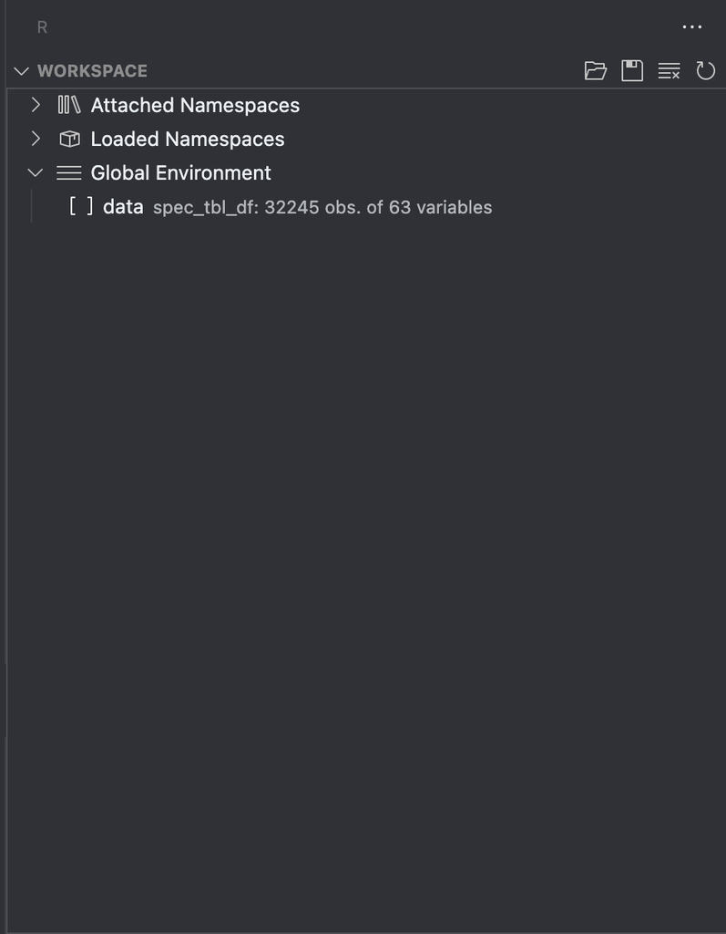

5. Instale e carregue os pacotes de R necessários para sua análise (mostre o código necessário):
   1. tidyverse
   - Para instala: `install.package("tidyverse")`
   - Para carregar: `library(tidyverse)`
   2. ggplot
   - Para instala: `install.package("ggplot2")`
   - Para carregar: `library(ggplot2)`
   3. summarytools
   - Para instala: `install.package("summarytools")`
   - Para carregar: `library(summarytools)`
   - Para o caso de *summarytools* tive problemas com a dependência *stringi*, para resolver foi necessário instala-la: `install.package("stringi")`